# Understanding How to Increase a Best Press

## Background

Powerlifting is an olympic strength sport that depends on lifting as much weight as possible in the categories of bench press, squat, and deadlift. Powerlifters have 3 attempts at each exercise to lift the most weight possible which will then be accumulated for a total score. Powerlifters are also allowed equipment in order to help them lift more weight. The bench press is commonly the most favored exercise and many are searching to understand what accounts for an increase in the best bench press weight. Data was gathered from several power lifting competitions in order to understand this question further.

## Pairs plot

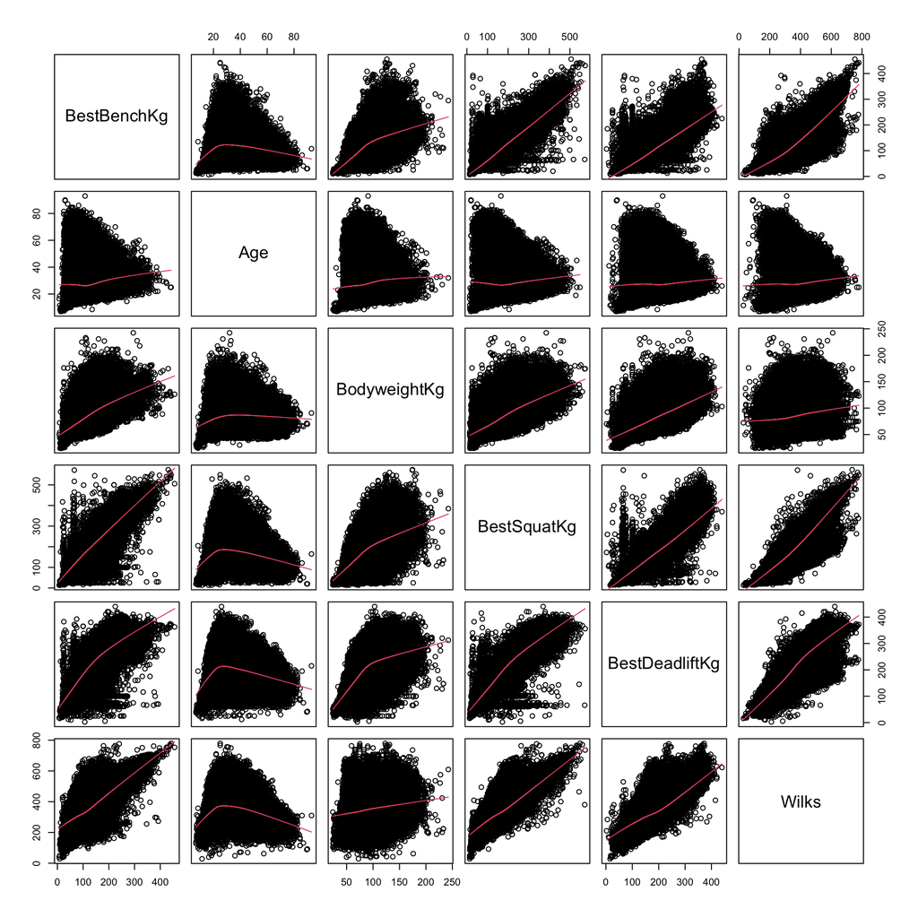

```r
# What influences someones bench press?
pairs(power.data, panel = panel.smooth)
```

```r
# Testing new lm equations

mydata2 <- mydata %>%
  filter(BestBenchKg > 0) %>%
  filter(BestSquatKg > 0) %>%
  filter(BestDeadliftKg > 0)

# Rsquared: 72.15
mylm <- lm(BestBenchKg ~ BestSquatKg
           + Sex
           + Equipment
           + BestSquatKg:Sex
          + BestSquatKg:Equipment
           ,data = mydata2)
#summary(mylm)

# Rsquared: 82.1

mylm <- lm(BestBenchKg ~ BestSquatKg
           + Sex
           + BestSquatKg:Equipment
           ,data = mydata2)
#summary(mylm)
```

# Regression Model

Below is the mathematical model that represents what accounts for the best bench press of a lifter. Although it may be hard to understand initially, these are what each variables represent:

$\hat{Y}_i$: represents the estimated best bench press from the given the regression equation

$b_0$: represents the best bench press when the best squat is 0 kg

$b_1$: represents the best squat of the lifter in kilograms

$b_2$: represents the genders sex (this will cause the lines to differ in their intercepts)

$b_3$: represents the interaction between the best squat of a lifter and their equipment used (this will cause the slopes to change between equipment used)

$$\underbrace{\hat{Y}_i}_{\text{Best Bench (kg)}} = b_0
+ b_1 \underbrace{X_{1i}}_{\text{Best Squat (kg)}}
+ b_2 \underbrace{X_{2i}}_{\text{Sex}}
+ b_3 \underbrace{X_{1i} X_{4i}}_{\text{Best Squat (kg) * Equipment}} +
\epsilon_i$$

The mathematical model above represents the same data. However, this mathematical model represents the data observed. The larger B’s found in the model are called ‘betas’ and represent the true mathematical model that accounts for a powerlifters best bench press. However, these are estimated in the model above by the ‘b’ values. Continually, you’ll notice that there is an $\epsilon_i$ at the end of this model, this is called an ‘epsilon’ which causes the data points to deviate away from the regression line, think of this as ‘errors’ since they aren’t always perfectly on the regression line.

## Hypothesis & Model Summary

# Testing the Slope of the Baseline

# Understanding the Y-int

The estimate given for the y-int is -3.18 (represented by $b_0$) with a p-value less than 2e-16 which is less than 0.05 meaning that it’s also considered significant. However, the y-int for this regression isn’t interpretable since it’s not reasonable for someone to squat 0 pounds or bench press negative weight as a powerlifter.

# Testing the Interaction of Squat to ‘Raw’ Equipment

$b_3$ being 0 would imply that the slope of best squat for those with ‘raw’ equipment does not differ from that of ‘multiply’ equipment. $b_3$ not being 0 would imply that the slope for best squat for those with ‘raw’ equipment does differ from those with ‘multiply’ equipment. As displayed below in the summary table, the p-value is <2e-16 which is significantly less than 0.05 meaning that the relationship of best bench press and best squat differ for both groups of equipment used. Continually, the estimate below is displayed as -0.0330829. This represents how much the relationship differs from the ‘multiply’ line, in other words the slope for those who squatted with ‘raw’ equipment is -0.0330829 less than that of ‘multiply’.

$$H_0: \beta_3 = 0 \quad \text{(Equal rates growth)} \\
H_a: \beta_3 \neq 0 \quad \text{(Non-equal rates of growth)}$$

# Testing the Interaction of Squat to ‘Singleply’ Equipment

$b_4$ being 0 would imply that the slope of best squat for those with ‘singeply’ equipment does not differ from that of ‘multiply’ equipment. $b_4$ not being 0 would imply that the slope for best squat for those with ‘singeply’ equipment does differ from those with ‘multiply’ equipment. As displayed below in the summary table, the p-value is <2e-16 which is significantly less than 0.05 meaning that the relationship of best bench press and best squat differs for both groups of equipment used. Continually, the estimate below is displayed as -0.0644137. This represents how much the relationship differs from the multiply line. It’s important to recognize that even though $b_4$ was not displayed in the regression equation above, this is incorporated into $b_3$ in the regression equation since that is the variable that changes the slope depending on the equipment used, however the independent change from ‘multiply’ to ‘singely’ was tested for $b_4$.

$$H_0: \beta_4 = 0 \quad \text{(Equal rates growth)} \\
H_a: \beta_4 \neq 0 \quad \text{(Non-equal rates of growth)}$$

# Testing the Interaction of Squat to ‘Wraps’ Equipment

$b_5$ being 0 would imply that the slope of best squat for those with ‘wraps’ equipment does not differ from that of ‘multiply’ equipment. $b_5$ not being 0 would imply that the slope for best squat for those with ‘wraps’ equipment does differ from those with ‘multiply’ equipment. As displayed below in the summary table, the p-value is <2e-16 which is significantly less than 0.05 meaning that the relationship of best bench press and best squat differ for both groups of equipment used. Continually, the estimate below is displayed as -0.0454318. This represents how much the relationship differs from the multiply line. It’s important to recognize that even though $b_5$ was not displayed in the regression equation above, this is incorporated into $b_3$ in the regression equation since that is the variable that changes the slope depending on the equipment used, however the independent change from ‘multiply’ to ‘wraps’ was tested for $b_5$.

$$H_0: \beta_5 = 0 \quad \text{(Equal rates growth)} \\
H_a: \beta_5 \neq 0 \quad \text{(Non-equal rates of growth)}$$

## Understanding the Model

```r
summary(mylm)
```

```
##
## Call:
## lm(formula = BestBenchKg ~ BestSquatKg + Sex + BestSquatKg:Equipment,
##     data = mydata2)
##
## Residuals:
##     Min      1Q  Median      3Q     Max
## -312.01  -11.87   -1.63    9.56  359.63
##
## Coefficients:
##                                   Estimate Std. Error t value Pr(>|t|)
## (Intercept)                     -3.1848445  0.1151024  -27.67   <2e-16 ***
## BestSquatKg                      0.6365605  0.0010090  630.87   <2e-16 ***
## SexM                            17.1514393  0.1072350  159.94   <2e-16 ***
## BestSquatKg:EquipmentRaw        -0.0330829  0.0010109  -32.73   <2e-16 ***
## BestSquatKg:EquipmentSingle-ply -0.0644137  0.0009957  -64.69   <2e-16 ***
## BestSquatKg:EquipmentWraps      -0.0454318  0.0010369  -43.81   <2e-16 ***
## ---
## Signif. codes:  0 '***' 0.001 '**' 0.01 '*' 0.05 '.' 0.1 ' ' 1
##
## Residual standard error: 20.26 on 286639 degrees of freedom
## Multiple R-squared:  0.821,  Adjusted R-squared:  0.821
## F-statistic: 2.629e+05 on 5 and 286639 DF,  p-value: < 2.2e-16
```

Continually, on the bottom is the residual standard error. This is a measure of the overall deviation or error between the predicted values (found on the regression line) and the actual observed values in a linear regression model. It represents the average amount of variability in the response variable that is not explained by the model. A lower RSE indicates that the model fits the data better, whereas a higher RSE indicates that the model may not be capturing all of the important factors that influence the y-variable, being the best bench press. The residual standard error is 20.26 as shown in the summary table above. This means that 20.26(kg) is the average amount that the data deviates from the estimated regression line.

Lastly, at the bottom right of this table is the adjusted r-squared. R-squared is a measure that tells us how well a line (or curve) fits a set of data. It ranges from 0 to 1, with 1 being the best possible fit. A higher r-squared value means that the line is a better predictor of the data, but it may not always mean that the line causes the data. The r-squared is shown to be 0.821 which is considerably high and means that 82.1% of the variability observed in the best bench press is explained by the regression model above. In other words, this tells us how well the data fit the regression and it appears to be a good fit!

## Visualizing the Model

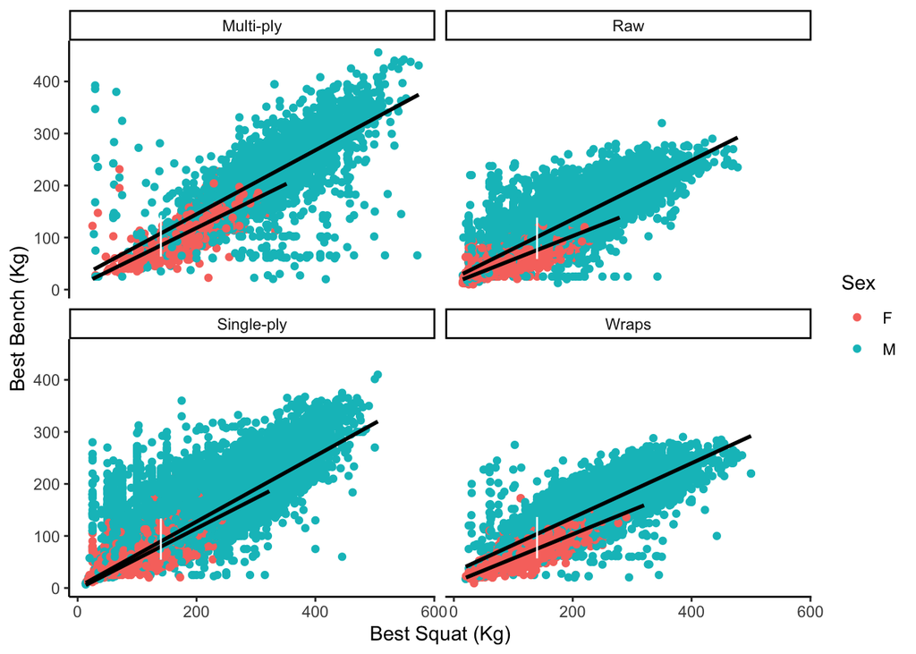

```r
library(ggplot2)
# Data for Raw Deadlift
my.pred1 <- predict(mylm, newdata=data.frame(BestSquatKg = 140,
                                              Sex='M',
                                            Equipment = 'Raw'),interval = 'prediction')

data.raw <-data.frame(x=140,y=my.pred1[2],xend=140,yend=my.pred1[3],
                      Equipment="Raw")

# Data for Multiple Layered Deadlift
my.pred2 <- predict(mylm, newdata=data.frame(BestSquatKg = 140,
                                              Sex='M',
                                            Equipment = 'Multi-ply'),interval = 'prediction')

data.mult<- data.frame(x=140,y=my.pred2[2],xend=140,yend=my.pred2[3],
                      Equipment="Multi-ply")

# Data for Single Layered Deadlift

my.pred3 <- predict(mylm, newdata=data.frame(BestSquatKg = 140,
                                              Sex='M',
                                            Equipment = 'Single-ply'),interval = 'prediction')

data.sing<- data.frame(x=140,y=my.pred3[2],xend=140,yend=my.pred3[3],
                      Equipment="Single-ply")

# Data for wraps deadlift

my.pred4 <- predict(mylm, newdata=data.frame(BestSquatKg = 140,
                                              Sex='M',
                                            Equipment = 'Wraps'),interval = 'prediction')

data.wrap<- data.frame(x=140,y=my.pred4[2],xend=140,yend=my.pred4[3],
                      Equipment="Wraps")



ggplot(mydata2, aes(x = BestSquatKg, y = BestBenchKg, color = Equipment)) +
  geom_point(aes(color = Sex)) +
    geom_smooth(method = "lm", aes(group = interaction(Sex, Equipment)), se = FALSE, color = 'black') +
  geom_segment(data=data.raw,
               aes(x=x,y=y,yend=yend,xend=xend),inherit.aes=FALSE, col = 'white') +
  geom_segment(data=data.mult,
               aes(x=x,y=y,yend=yend,xend=xend),inherit.aes=FALSE, col = 'white') +
  geom_segment(data=data.sing,
               aes(x=x,y=y,yend=yend,xend=xend),inherit.aes=FALSE, col = 'white') +
  geom_segment(data=data.wrap,
               aes(x=x,y=y,yend=yend,xend=xend),inherit.aes=FALSE, col = 'white') +
  labs(x = "Best Squat (Kg)", y = "Best Bench (Kg)") +
  scale_color_discrete(name = "Sex") +
  scale_linetype_discrete(name = "Sex") +
  facet_wrap(~Equipment) +
  theme_classic()
```

Above is the graph of the model. The y-axis represents the bench bench press in kilograms for each lifter and the x-axis represents the best squat in kilograms for each lifter. Each line also represents a different equipment used since they are understood to vary from one another. For further context, ‘multiply’ is multiple layers of supportive material worn by the lifter, ‘raw’ means that no equipment was used, ‘single-ply’ refers to one piece of supportive material used such as a lifting belt or knee sleeves, and ‘wraps’ refers to wrist wraps.

The lines you see on the graph are the regression lines and give us an estimate of the best bench press that a lifter will achieve, based on their best squat. Continually, you’ll notice that there are vertical white line on the black regression lines, these are prediction intervals. Prediction intervals give us a range of values that an observation is likely to fall within, based on the data and the model used to make the prediction. They take into account the variability in the data and the accuracy of the model, and provide an estimate of the range of possible outcomes, rather than just a single point estimate. They are corresponding to the ‘higher’ or ‘steeper’ line since these are the lines that represent the male powerlifters. These prediction intervals are telling what the predicted best bench press is for a man with a 140 kg squat for each different lifting equipment.

## Verifying the Model

When it comes to verifying the model, there are 5 assumptions that must be verified for the linear regression model. Including: (1) The regression relationship between X & Y is linear. (2) The error terms are normally distributed with $E\{\epsilon_i\}=0$ (3)The variance of the error terms is constant over all X values (4) the X values can be considered fixed and measured without error. and (5 ) the error terms are independent

Below are plots that can be used to verify the above assumptions for linear regression models.

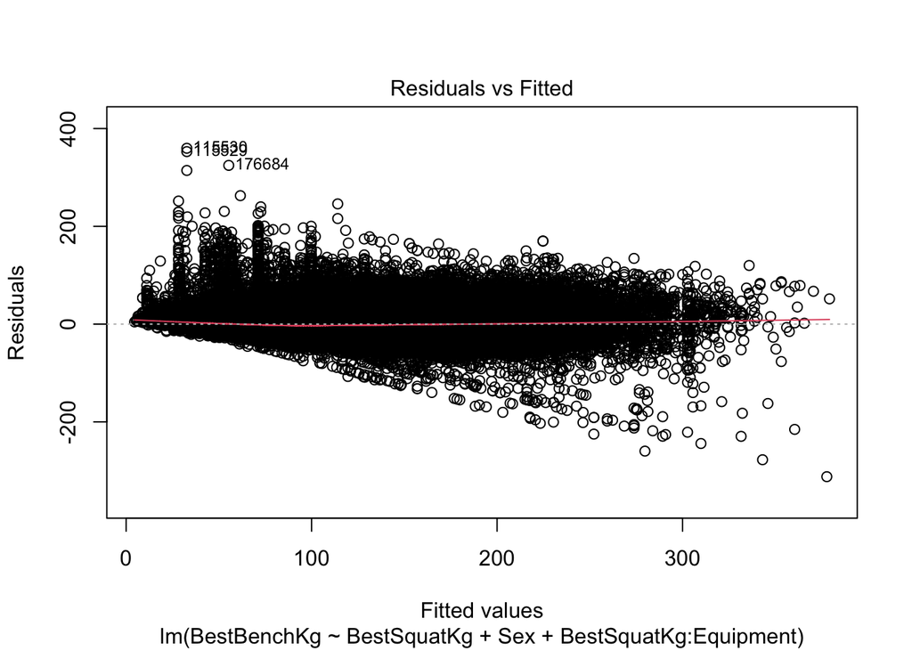

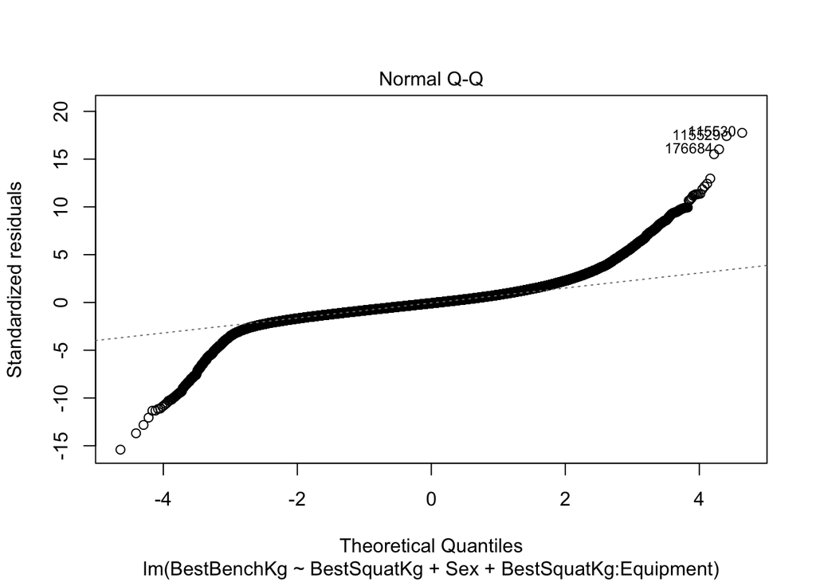

```r
 plot(mylm, which = 1:2)
```

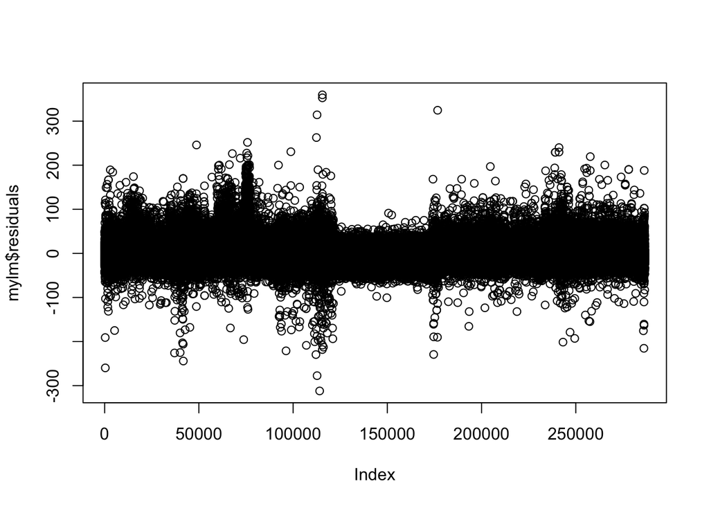

```r
 plot(mylm$residuals)
```

In the second plot, we are looking to see that the data points are as close to the dotted line as possible. These points are what’s called ‘residuals’ which in essence are the distance from the actual data points observed to the estimated line (the black lines that are in the model above). If these data points clearly follow the dotted line, this means that the error terms are normally distributed (since the residuals are in essence the models error). It appears that both ends of the line deviate from the dotted line a fair amount. This would imply that the data is ‘heavy tailed’ meaning that there are a lot of outliers on either end of the data (low or high). This means that there are several observations that are much larger than the rest of the data. However, this shouldn’t invalidate the results of the test since it helps us understand that the residuals are larger on either end of the regression line.

With a further understanding of these assumptions and their qualifications, it can be assumed that the regression given is a good fit for the data and will help in our understanding in what accounts for a powerlifters best bench press.

```r
# let's validate our model
set.seed(121)
keep <- sample(1:nrow(mydata2),14000)

mytrain <- mydata2[keep, ]
mytest <- mydata2[-keep,]

mylm <- lm(BestBenchKg ~ BestSquatKg
           + Sex
           + BestSquatKg:Equipment
           ,data = mydata2)


myprediction <- predict(mylm, mytrain)
```

## Conclusion

In conclusion it appears that squatting and equipment accounts for the biggest differences in increasing someones bench press. This is likely because of the overall strength of the powerlifter and the incorporation of compound exercises in their workouts which include the bench press and squat. Continually, the equipment also reflects the overall utilities that powerlifters use in their training to help them lift more weight. Thus it’s essential that a powerlifter utilizes their use of equipment, especially multiply as well as work on their overall strength in their squat in order to improve their bench press.